# Modelisation de la Cinétique des Protéines

Sophie Donnet

2022-09-28

## 1. Contexte

On s’intéresse à des images composées de points verts et rouges, chaque point correspondant à un bout précis de l’ADN. Quand ces bouts d’ADN ont été lus, la particule s’éteint. Cependant, ces particuliers s’éteignent aussi même sans avoir été lus (parce que éclairés trop longtemps par exemple). On note $i$ un bout d’ARN représenté par un point vert et un point rouge. Soit $n$ leur nombre. Après traitement d’image, on peut observer sur un intervalle de temps donné $[T_0, T]$, les instants de mort
$$(T_i^R, T^V_i)_{i=1,\dots n}.$$
Deux processus de morts sont à l’oeuvre et se cumulent:

- Mort naturelle (dûe à la durée de l’éclairage)
- Mort par lecture

Pour toute entité $i$, soit $U_i^{R}$ l’instant de mort naturelle de la particule $R$ (idem pour $V$) et soit $V_i^{R}$ sa mort par lecture.

Alors

$$\begin{aligned}
T_i^{R} &= \min(U_i^{R},V_i^R)\\
T_i^{V} &= \min(U_i^{V},V_i^V)
\end{aligned}$$

De plus, par lecture le long du ribosome, la verte s’éteint avant la rouge.

$$V_i^R > V_i^V$$

## 2. Données

On observe deux types de données.

-Expérience 1 : données de contrôle permettent d’observer le phénomène de mort naturelle $(T_i^{C})_{i=1, \dots,n_C}$.

-Expérience 2 : expérience de lecture $(T_i^{R}, T_i^V)_{i=1, \dots,n}$.

## Le modèle

### les 2 couleurs en même temps

$$\left\{
\begin{array}{cclcl}
U_i^R &\sim& \mathcal{F}(\theta_{N}) &=&
\Gamma(\alpha_N,\beta_N)\\
U_i^V &\sim& \mathcal{F}(\theta_{N}) &=&
\Gamma(\alpha_N,\beta_N) \\
V_i^V &\sim& \mathcal{F}(\theta_{L}) &=&
\mathcal{E}(\lambda_c) + \Gamma(k, \lambda_e) \\
V_i^R &\sim& V_i^V + \mathcal{F}(\nu_{L}) &=& V_i^V +
\Gamma(k', \lambda_e) \\
T_i^{R} &=& \min(U_i^{R},V_i^R)\\
T_i^{V} &=& \min(U_i^{V},V_i^V)
\end{array}
\right.$$

$\alpha_N$ et $\beta_N$ sont les paramètres de mort spontanée. $\lambda_c$ représente le temps pour que la particule de rejoindre la protéine. $k$ est le nombre de codons. $\lambda_e$ est le paramètre de lecture pour chaque codon . $k'$ est le nombre de codons entre le début et la fin de la séquence.

### Si on considère couleur par couleur

On enlève l’exposant $R$ et $V$.

Par ailleurs, on remplace $\mathcal{E}(\lambda_c) + \Gamma(k, \lambda_e)$ par une *Exponentially modified Gaussien* dont la densité est encodée sour R dans le package `emg`.

$$\left\{
\begin{array}{cclcl}
U_i &\sim& \Gamma(\alpha_N,\beta_N)\\
V_i &\sim& \mathcal{E}(\lambda_c) + \mathcal{N}(\mu, \sigma)
\quad \mbox{ avec } \mu=\frac{k}{\lambda_e} \quad \mbox{ et } \quad
\sigma^2 = \frac{k}{\lambda_e^2}\\
T_i &=& \min(U_i,V_i)\\
\end{array}
\right.$$
On choisit les valeurs suivantes:

On choisit les valeurs suivantes

- $\alpha_N=$ 1, $\beta_N=$ 0.0142857
- $\frac{1}{\lambda_e}=$ 3
- $\frac{1}{\lambda_c}=$ 3
- $k=$ 16

On peut alors tracer les densités différents phénomènes.

**Phénomène de lecture**

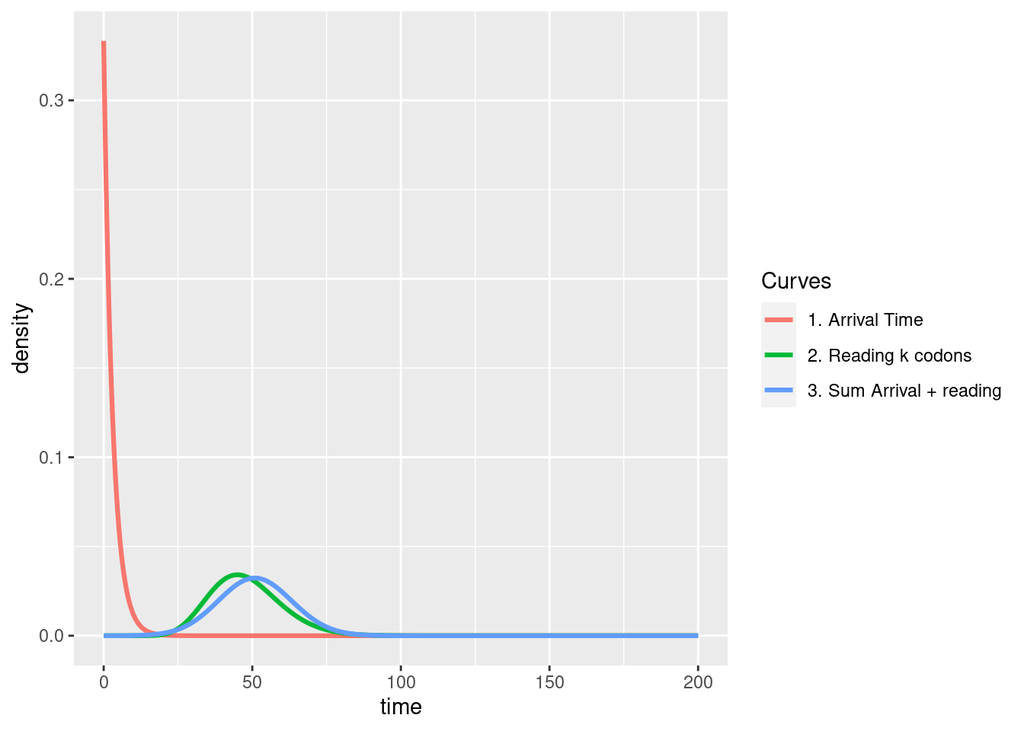

- La courbe rouge correspond au phénomène d’arrivée sur le lieu de lecture (paramètre $\lambda_c$)
- La courbe verte correspond au phénomène de elcture des $k$ codons (Gamma remplacée par la gaussienne)
- La courbe bleue est la somme des 2 temps.

**Phénomène de mort naturelle et lecture (min des deux)**

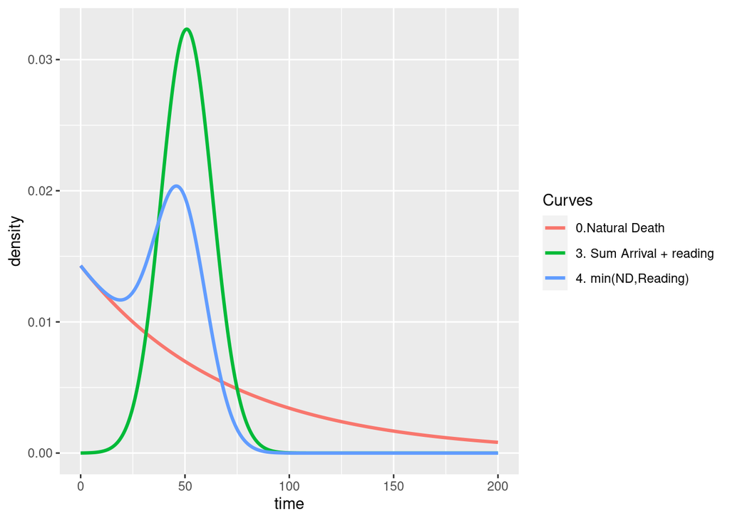

On retrouve bien la bosse du début.

**Phénomène de mort subite + phénomène précédent**

On peut ajouter un phénomène de mort subite. On dit qu’une partie $\pi_{QD}$ va mourir tout de suite et que l’autre proportion va subir le phénomène précédent.

Dans ce cas
$$T_i \sim \pi_{QD}
\Gamma(\alpha_{QD},\beta_{QD}) +
(1-\pi_{QD}) \min(\Gamma(\alpha_N,\beta_N),EMG(\lambda_c,
\mu,\sigma))$$

où $QD$ est pour “Quick Death”.

On choisit les valeurs suivantes:

- $\pi_{QD}=$ 0.1
- $\alpha_{QD}=$ 1
- $\beta_{QD}=$ 0.1

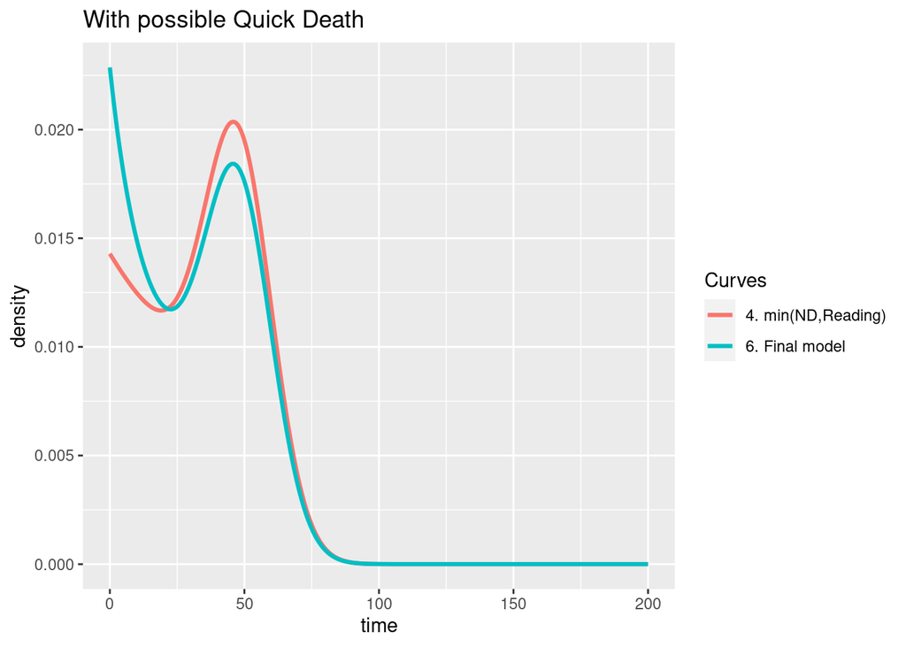

Ca va augmenter l’effet de la première bosse.

### Conclusion

Avec le modèle proposé on retrouve cette histoire de première bosse (même sans l’effet de Quick death). Maintenant, il faut retrouver les paramètres à partir de vos données!